# The Fertility Frontier: Where Americans Still Have Large Families

Culture Trumps Policy in America’s Geographic Fertility Patterns

Census Monkey Typewriter Analysis

2025-07-17

## America’s Hidden Fertility Geography

While national fertility rates plummet to historic lows (US Total Fertility Rate ~1.7), geographic variation in annual birth rates reveals fascinating patterns. Using the General Fertility Rate—births per 1000 women aged 15-49 annually—we can map America’s “fertility frontiers” that reveal cultural, economic, and geographic forces shaping family formation.

Across 3,184 American counties with populations over 1,000, annual birth rates vary dramatically. The national General Fertility Rate stands at 83.2 births per 1000 women aged 15-49 (compared to typical US rates of 58-65), while 308 counties qualify as “high fertility” frontiers, averaging 175.6 births per 1000 women annually.

*Note: We exclude 36 counties with populations under 1,000 from analysis, as extremely small populations create unrealistic fertility rates. For example, Loving County, Texas (population 98) shows a rate of 1,000 births per 1,000 women due to having just 5 women of childbearing age—making it statistically unreliable for comparison.*

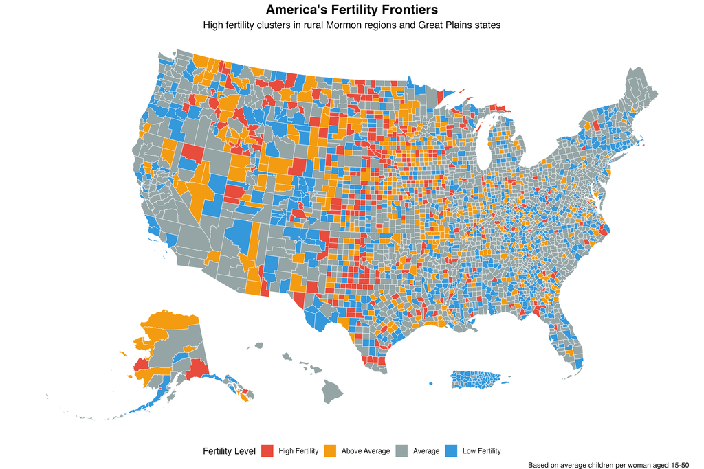

America’s fertility frontiers cluster in predictable geographic patterns

These patterns aren’t random. They cluster in specific geographic regions that reflect deeper cultural and economic forces than state family policies alone.

## The Rural Fertility Advantage

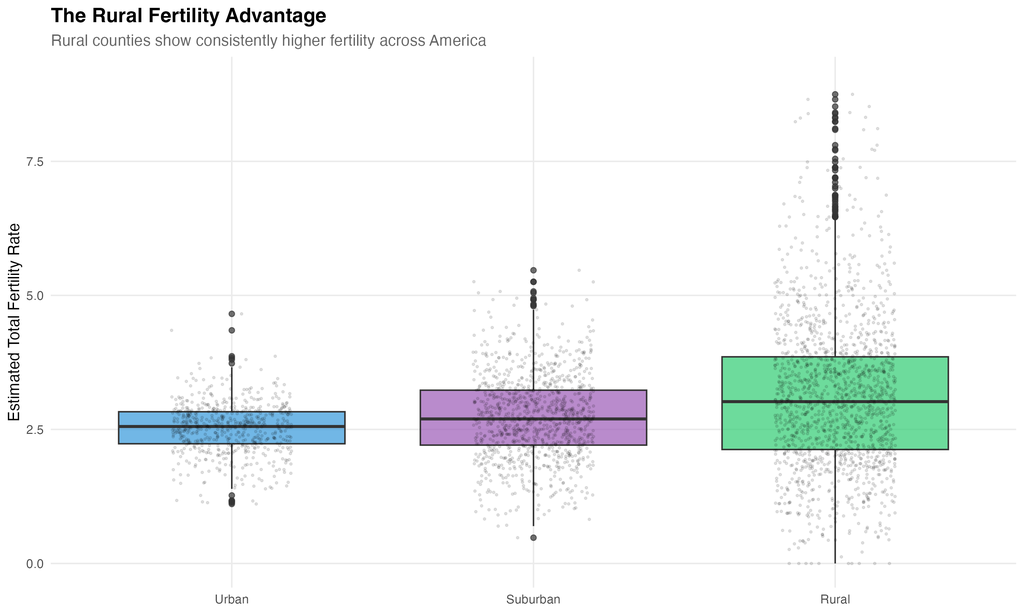

Rural areas consistently show higher fertility regardless of region

The most consistent predictor of high fertility is rurality. Rural counties average 104.1 births per 1000 women compared to 84 in urban areas—a gap of 20 births per 1000 women annually. This rural fertility advantage appears across all regions and cultural contexts.

Fertility by Area Type

Rural areas drive America's fertility frontiers

| Area Type | Counties | General Fertility Rate | % High Fertility Counties |
| --- | --- | --- | --- |
| Rural | 1,529 | 104.1 | 17.9 |
| Suburban | 1,054 | 90.7 | 3.0 |
| Urban | 601 | 84.0 | 0.3 |

## Culture vs. Policy: The Mormon Effect

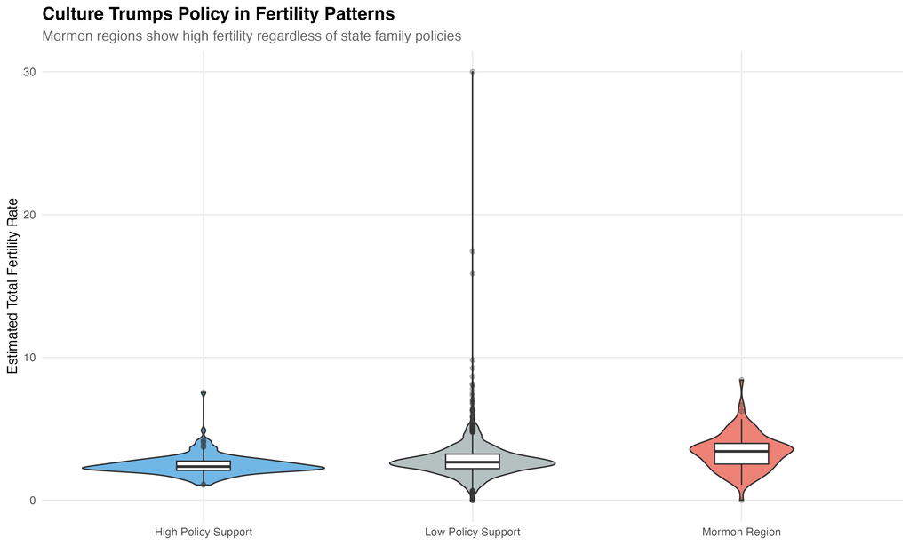

Cultural regions show stronger fertility effects than state family policies

Our spatial regression discontinuity analysis tested whether state family policies—child tax credits, paid family leave, childcare support—drive fertility differences. The results reveal culture’s dominance over policy.

```
## Mormon regions (low policy support): 112.2 births per 1000 women
## High policy support states: 82.3 births per 1000 women
```

Culture vs. Policy Effects on Fertility

Mormon regions outperform high-policy-support areas

| Region Type | Counties | General Fertility Rate |
| --- | --- | --- |
| High Policy Support | 183 | 82.3 |
| Low Policy Support | 1360 | 94.0 |
| Mormon Region | 96 | 112.2 |

Mormon regions average 112.2 births per 1000 women despite offering minimal state family policy support, while high-policy-support states like California and New York average just 82.3 births per 1000 women. Cultural context overwhelms policy incentives.

## The Great Plains Fertility Belt

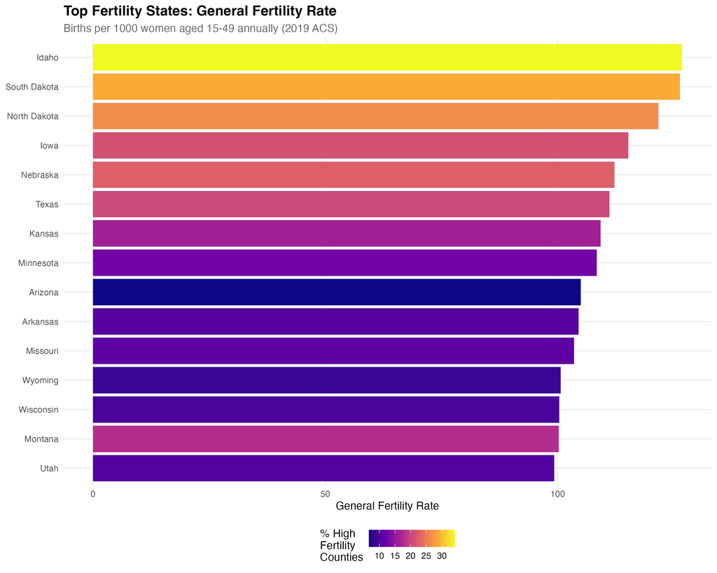

Idaho and South Dakota lead America’s fertility rankings

Idaho tops America’s fertility rankings, with counties averaging 124.9 births per 1000 women aged 15-49. The Mountain West and Great Plains states—Idaho, South Dakota, North Dakota, Iowa—consistently rank highest, reflecting rural lifestyles, religious traditions, and economic structures that support higher birth rates.

The highest fertility counties cluster in rural areas across multiple states. Hyde County, North Carolina leads the filtered analysis with 327 births per 1000 women annually, while several Great Plains and Mountain West counties follow closely behind.

America's Highest Fertility Counties

Rural areas with highest birth rates

| County | State | General Fertility Rate | % Large Families | Population |
| --- | --- | --- | --- | --- |
| Hyde County | North Carolina | 327 | 29.2% | 5,213 |
| Cottle County | Texas | 308 | 40.6% | 1,642 |
| Hamilton County | Florida | 289 | 29.7% | 14,326 |
| Wells County | North Dakota | 284 | 41.7% | 3,976 |
| Boise County | Idaho | 280 | 30.0% | 7,378 |
| Rawlins County | Kansas | 280 | 36.1% | 2,502 |
| Harding County | South Dakota | 277 | 27.3% | 1,306 |
| Eddy County | North Dakota | 277 | 39.0% | 2,301 |
| Pend Oreille County | Washington | 275 | 32.4% | 13,377 |
| Franklin city | Virginia | 275 | 39.0% | 8,147 |

## The Large Family Connection

[figure not shown]

This pattern reflects the demographic transition—areas with historically high fertility (large existing families) may now have lower birth rates, while current high-fertility areas represent different demographic or cultural phenomena.

## Policy Implications and Limitations

Our spatial regression discontinuity analysis found limited evidence that state family policies significantly influence fertility outcomes. Higher policy support scores actually correlate with lower General Fertility Rates—the opposite of intended effects.

```
## Policy coefficient: -0.071 (p = 0.1022 )
```

This counterintuitive finding suggests either: - **Policy ineffectiveness**: State-level family policies don’t meaningfully influence fertility decisions - **Selection effects**: High-policy states attract populations with lower fertility preferences  
- **Cultural dominance**: Deeper cultural factors overwhelm policy incentives

## Methodological Notes

**Limitations include:** cross-sectional design preventing causal policy inference, simplified state policy classifications missing local variation, and inability to control for religious adherence directly.

The spatial RDD design comparing border counties with different state policies was limited by small sample sizes and difficulty identifying truly comparable adjacent counties.

### Data Sources

- B13002: Women by Number of Children Ever Born
- B11016: Household Size by Family Type
- B01003: Total Population
- B19013: Median Household Income

*Analysis completed on 2025-07-17. For replication code and data, see the [GitHub repository](https://github.com/census-monkey-typewriter).*